# Influencing Factors on Internal Audit Maturity Using PLS-PM

Williamson Johnny H. Brigido, Ricardo Valerio de Lannes Maia and Jose M Parente de Oliveira

2024-01-06

# System Information

```r
set.seed(2024)
```

# Library

```r
#install.packages("formattable", dependencies=TRUE)
```

```r
#install.packages("rlist", dependencies=TRUE)
```

```r
library(plspm)
library(readxl)
require(pwr)
require(formattable)
library(car)
library(effectsize)
```

# Size of Sample

```r
sample<-pwr.f2.test(u=7, v=NULL, f2=0.15, sig.level=0.05, power=0.8)
sample[["v"]]+sample[["u"]]+1
```

```
## [1] 102.9149
```

```r
rm("sample")
```

# Variables Meaning

IAM: Internal Audit Maturity

QUAL: Qualification

STRATOR: Strategic Orientation

ASSES: Assessment

EVALRESP: Evaluate Responsibility

DRRELAREA: Direct Responsibility for Related Areas

INVAREA: Involvement Areas

PARTN: Partnership

TYPINF: Types of Information

# Reading DataFrame and Transformation

```r
table <-read_excel('Base tratada.xlsx', sheet = 'Base tratada', range = 'A1:AX1999')
table[is.na(table)] <- 0
```

```r
colnames(table)
```

```
##  [1] "AEXP"      "CIA"       "FPESQ"     "HTREIN"    "CODETIC"   "CARTA"
##  [7] "MANOPER"   "EAI"       "ICP"       "MISSAO"    "MAI"       "FAVEXT"
## [13] "FAVINT"    "FCOMRES"   "FCTERC"    "FRACONT"   "FRAGOV"    "FRAGR"
## [19] "ASOOC"     "PREST"     "BENCH"     "REMERG"    "CINTER"    "CNEG"
## [25] "ECASO"     "MPRAT"     "PAUDIT"    "MODEL"     "GUIA"      "RFCOAUD"
## [31] "RDCONFG"   "RDGR"      "RDETIC"    "RDFRAUD"   "RDGOVRC"   "RDCREPFIN"
## [37] "ECONF"     "ERCUSTO"   "ECIBER"    "EGR"       "EREPFIN"   "EFIN"
## [43] "EFRAUD"    "EGOVCULT"  "ETI"       "ERTERC"    "EOPER"     "EAUDEXT"
## [49] "ESUST"     "TERC"
```

```r
colnames(table)[1] <- "QUAL1" #AEXP para QUAL1
colnames(table)[2] <- "QUAL2" #CIA para QUAL2
colnames(table)[3] <- "QUAL3" #FPESQ para QUAL3
colnames(table)[4] <- "QUAL4" #HTREIN para QUAL4
colnames(table)[5] <- "STRATOR1" #CODETIC para STRATOR1
colnames(table)[6] <- "STRATOR2" #CARTA para STRATOR2
colnames(table)[7] <- "STRATOR3" #MANOPER para STRATOR3
colnames(table)[8] <- "STRATOR4" #EAI para STRATOR4
colnames(table)[9] <- "STRATOR5" #ICP para STRATOR5
colnames(table)[10] <- "STRATOR6" #MISSAO para STRATOR6
colnames(table)[11] <- "IAM" #IAM
colnames(table)[12] <- "ASSES1" #FAVEXT para ASSES1
colnames(table)[13] <- "ASSES2" #FAVINT para ASSES2
colnames(table)[14] <- "ASSES3" #FCOMRES para ASSES3
colnames(table)[15] <- "PARTN1" #FCTERC para PARTN1
colnames(table)[16] <- "EVALRESP1" #EVALRESPCONT para EVALRESP1
colnames(table)[17] <- "EVALRESP2" #EVALRESPGOV para EVALRESP2
colnames(table)[18] <- "EVALRESP3" #EVALRESPGR para EVALRESP3
colnames(table)[19] <- "PARTN2" #ASTRATOROC para PARTN2
colnames(table)[20] <- "PARTN3" #PREST para PARTN3
colnames(table)[21] <- "TYPINF1" #BENCH para TYPINF1
colnames(table)[22] <- "TYPINF2" #REMERG para TYPINF2
colnames(table)[23] <- "TYPINF3" #CINTER para TYPINF3
colnames(table)[24] <- "TYPINF4" #CNEG para TYPINF4
colnames(table)[25] <- "TYPINF5" #ECASTRATOR para TYPINF5
colnames(table)[26] <- "TYPINF6" #MPRAT para TYPINF6
colnames(table)[27] <- "TYPINF7" #PAUDIT para TYPINF7
colnames(table)[28] <- "TYPINF8" #MODEL para TYPINF8
colnames(table)[29] <- "TYPINF9" #GUIA para TYPINF9
colnames(table)[30] <- "STRATOR7" #RFCOAUD para OE7
colnames(table)[31] <- "DRRELAREA1" #RDCONFG para DRRELAREA1
colnames(table)[32] <- "DRRELAREA2" #RDGR para DRRELAREA2
colnames(table)[33] <- "DRRELAREA3" #RDETIC para DRRELAREA3
colnames(table)[34] <- "DRRELAREA4" #RDEVALRESPUD para DRRELAREA4
colnames(table)[35] <- "DRRELAREA5" #RDGOVRC para DRRELAREA5
colnames(table)[36] <- "DRRELAREA6" #RDCREPFIN para DRRELAREA6
colnames(table)[37] <- "INVAREA1" #ECONF para INVAREA1
colnames(table)[38] <- "INVAREA2" #ERCUSTO para INVAREA2
colnames(table)[39] <- "INVAREA3" #ECIBER para INVAREA3
colnames(table)[40] <- "INVAREA4" #EGR para INVAREA4
colnames(table)[41] <- "INVAREA5" #EREPFIN para INVAREA5
colnames(table)[42] <- "INVAREA6" #EFIN para INVAREA6
colnames(table)[43] <- "INVAREA7" #EEVALRESPUD para INVAREA7
colnames(table)[44] <- "INVAREA8" #EGOVCULT para INVAREA8
colnames(table)[45] <- "INVAREA9" #ETI para INVAREA9
colnames(table)[46] <- "INVAREA10" #ERTERC para INVAREA10
colnames(table)[47] <- "INVAREA11" #EOPER para INVAREA11
colnames(table)[48] <- "INVAREA12" #EAUDEXT para INVAREA12
colnames(table)[49] <- "INVAREA13" #ESUST para INVAREA13
colnames(table)[50] <- "PARTN4" #TERC para PARTN4
colnames(table)
```

```
##  [1] "QUAL1"      "QUAL2"      "QUAL3"      "QUAL4"      "STRATOR1"
##  [6] "STRATOR2"   "STRATOR3"   "STRATOR4"   "STRATOR5"   "STRATOR6"
## [11] "IAM"        "ASSES1"     "ASSES2"     "ASSES3"     "PARTN1"
## [16] "EVALRESP1"  "EVALRESP2"  "EVALRESP3"  "PARTN2"     "PARTN3"
## [21] "TYPINF1"    "TYPINF2"    "TYPINF3"    "TYPINF4"    "TYPINF5"
## [26] "TYPINF6"    "TYPINF7"    "TYPINF8"    "TYPINF9"    "STRATOR7"
## [31] "DRRELAREA1" "DRRELAREA2" "DRRELAREA3" "DRRELAREA4" "DRRELAREA5"
## [36] "DRRELAREA6" "INVAREA1"   "INVAREA2"   "INVAREA3"   "INVAREA4"
## [41] "INVAREA5"   "INVAREA6"   "INVAREA7"   "INVAREA8"   "INVAREA9"
## [46] "INVAREA10"  "INVAREA11"  "INVAREA12"  "INVAREA13"  "PARTN4"
```

# Triangular matrix

```r
path.matrix <- matrix(0, nrow = 9, ncol = 9)
path.matrix[9,]<-rep(1,9) # every variable explain IAM
path.matrix[9,9]<-0 # without feeedback
path.matrix[8,6]<-1 # effect from INVAREA to PARTN
path.matrix[8,3]<-1 # effect from DRRELAREA to PARTN
path.matrix[8,5]<-1 # effect from STRATOR to PARTN
path.matrix[7,5]<-1 # effect from STRATOR to TYPINF
path.matrix[6,5]<-1 # effect from STRATOR to INVAREA
path.matrix[7,3]<-1 # effect from DRRELAREA to TYPINF
colnames(path.matrix)=rownames(path.matrix)<-c("ASSES","QUAL","DRRELAREA", "EVALRESP", "STRATOR", "INVAREA", "TYPINF", "PARTN","IAM")
```

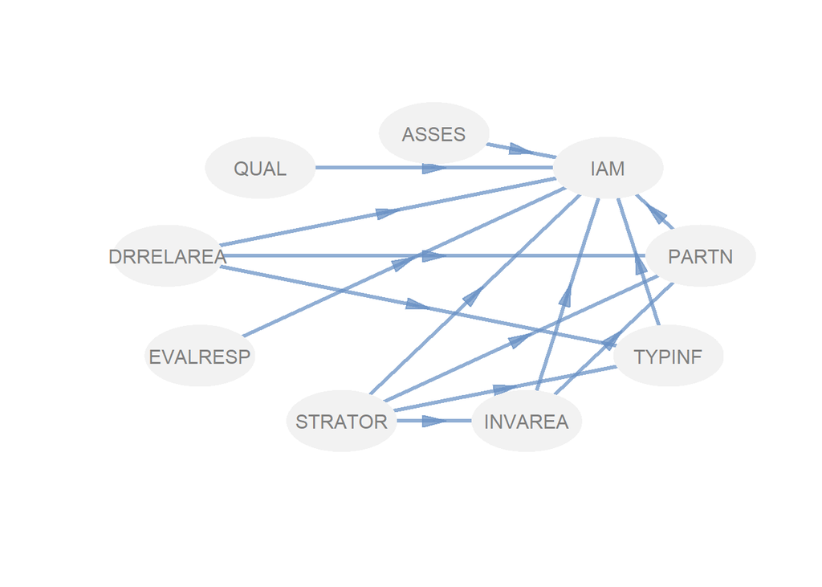

```r
innerplot(path.matrix)
```

# Block Variable

## Defining the block of variables. Each line is a latent variable

## Each indicators present in line is the relection of the LV.

```r
block.indicators <- list(
    c('ASSES1','ASSES2', 'ASSES3'), #faq
    c('QUAL1','QUAL2','QUAL3','QUAL4'), #QUAL
    c('DRRELAREA1','DRRELAREA2','DRRELAREA3','DRRELAREA4','DRRELAREA5','DRRELAREA6'),
    c('EVALRESP1','EVALRESP2', 'EVALRESP3'),
    c('STRATOR1','STRATOR2','STRATOR3','STRATOR4','STRATOR5','STRATOR6','STRATOR7'),
    c('INVAREA1','INVAREA2','INVAREA3','INVAREA4','INVAREA5','INVAREA6','INVAREA7','INVAREA8','INVAREA9','INVAREA10','INVAREA11','INVAREA12','INVAREA13'),
    c('TYPINF1','TYPINF2','TYPINF3','TYPINF4','TYPINF5','TYPINF6','TYPINF7','TYPINF8','TYPINF9'),
   c("PARTN1","PARTN2","PARTN3","PARTN4"),
   c('IAM'))
```

# Scale Definition

## Definig the scale (what is numeric and what is nominal=non-metric)

```r
scaled <- list(
    rep("NOM",3), #faq
    c("NUM", "NOM","NOM","NUM"), #QUAL
    rep("NOM",6), #rdac
    rep("NOM",3), #fra
    rep("NOM",7), #STRATOR
    rep("NOM",13), #ec
    rep("NOM",9), #bia
    c("NOM", "NOM","NOM","NUM"), #pt
    c("NUM") #mai
    )
```

# Reflexive Mode

## All Latent Variables are reflexive

```r
modes <- rep("A",9)
```

# External Model Validation

## First running to measure indicators

```r
model_pls1 = plspm(table,
                    path.matrix,
                    block.indicators,
                    modes = modes,
                    scaling = scaled,
                    scaled = TRUE,
                    scheme = "path",
                    tol = 1e-7, #tolerância
                    maxiter=300, #número de interações máximas
                    boot.val =TRUE, #com bootstrapping
                    br=100) #número de amostra bootstrapping
```

# Alpha Cronbach, Rho, Eigenvalue

```r
options(repr.plot.width = 1, repr.plot.height = 0.75, repr.plot.res = 100)
formattable(model_pls1$unidim , list(
   C.alpha = formatter("span", style = x ~ ifelse(x < 0.7, style(color = "red", font.weight = "bold"), style(color = "green", font.weight = "bold"))),
   DG.rho = formatter("span", style = x ~ ifelse(x < 0.5, style(color = "red", font.weight = "bold"), style(color = "green", font.weight = "bold"))),
   eig.1st=color_tile("white", "yellow"),
   eig.2nd=color_tile("white", "purple")
))
```

|  | Mode | MVs | C.alpha | DG.rho | eig.1st | eig.2nd |
| --- | --- | --- | --- | --- | --- | --- |
| ASSES | A | 3 | 0.7463813 | 0.85564981 | 1.993188 | 0.5923898 |
| QUAL | A | 4 | 0.7557806 | 0.84582067 | 2.318345 | 0.7143565 |
| DRRELAREA | A | 6 | 0.8021518 | 0.85924359 | 3.043606 | 0.8220197 |
| EVALRESP | A | 3 | 0.6039255 | 0.79126296 | 1.677185 | 0.7377764 |
| STRATOR | A | 7 | 0.8997010 | 0.92140957 | 4.392699 | 0.6712617 |
| INVAREA | A | 13 | 0.8713187 | 0.89423412 | 5.156630 | 1.0539624 |
| TYPINF | A | 9 | 0.9112693 | 0.92779984 | 5.320419 | 0.8108628 |
| PARTN | A | 4 | 0.1567167 | 0.01751683 | 1.262489 | 1.1879879 |
| IAM | A | 1 | 1.0000000 | 1.00000000 | 1.000000 | 0.0000000 |

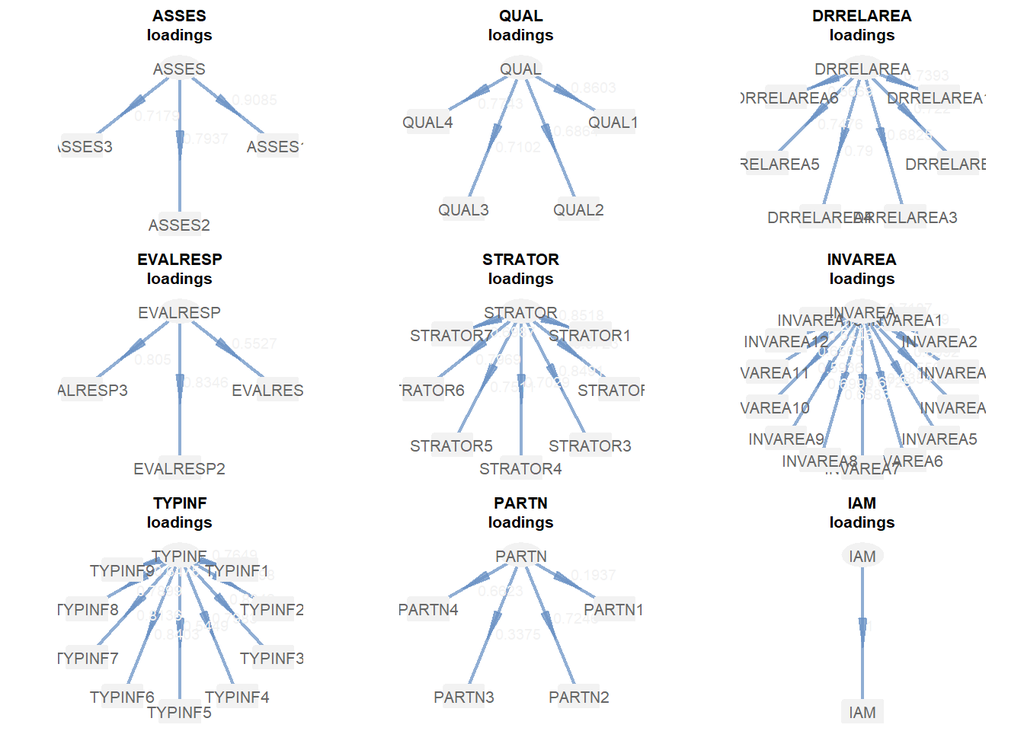

```r
plot(model_pls1, what="loadings", arr.width = 0.1)
```

```r
options(repr.plot.width = 1, repr.plot.height = 0.75, repr.plot.res = 100)
formattable(model_pls1$outer_model, list(
    loading = formatter("span", style = x ~ ifelse(x < 0.7, style(color = "red", font.weight = "bold"), style(color = "green", font.weight = "bold"))),
   communality = formatter("span", style = x ~ ifelse(x < 0.5, style(color = "red", font.weight = "bold"), style(color = "green", font.weight = "bold"))),
   redundancy=color_tile("white", "yellow")
))
```

| name | block | weight | loading | communality | redundancy |
| --- | --- | --- | --- | --- | --- |
| ASSES1 | ASSES | 0.56934845 | 0.9084924 | 0.82535837 | 0.00000000 |
| ASSES2 | ASSES | 0.33541023 | 0.7937113 | 0.62997759 | 0.00000000 |
| ASSES3 | ASSES | 0.30159958 | 0.7179466 | 0.51544737 | 0.00000000 |
| QUAL1 | QUAL | 0.40147330 | 0.8602531 | 0.74003544 | 0.00000000 |
| QUAL2 | QUAL | 0.26194010 | 0.6864366 | 0.47119514 | 0.00000000 |
| QUAL3 | QUAL | 0.29467413 | 0.7101656 | 0.50433512 | 0.00000000 |
| QUAL4 | QUAL | 0.34297885 | 0.7742713 | 0.59949597 | 0.00000000 |
| DRRELAREA1 | DRRELAREA | 0.22326949 | 0.7392682 | 0.54651742 | 0.00000000 |
| DRRELAREA2 | DRRELAREA | 0.22820717 | 0.7219880 | 0.52126667 | 0.00000000 |
| DRRELAREA3 | DRRELAREA | 0.23658608 | 0.6824689 | 0.46576378 | 0.00000000 |
| DRRELAREA4 | DRRELAREA | 0.28993479 | 0.7900188 | 0.62412963 | 0.00000000 |
| DRRELAREA5 | DRRELAREA | 0.22278888 | 0.7475733 | 0.55886578 | 0.00000000 |
| DRRELAREA6 | DRRELAREA | 0.19953889 | 0.5668748 | 0.32134705 | 0.00000000 |
| EVALRESP1 | EVALRESP | 0.23604765 | 0.5527463 | 0.30552847 | 0.00000000 |
| EVALRESP2 | EVALRESP | 0.55143533 | 0.8346194 | 0.69658954 | 0.00000000 |
| EVALRESP3 | EVALRESP | 0.50842656 | 0.8050069 | 0.64803618 | 0.00000000 |
| STRATOR1 | STRATOR | 0.19424368 | 0.8518098 | 0.72557988 | 0.00000000 |
| STRATOR2 | STRATOR | 0.22900262 | 0.8722600 | 0.76083756 | 0.00000000 |
| STRATOR3 | STRATOR | 0.19968139 | 0.8491360 | 0.72103203 | 0.00000000 |
| STRATOR4 | STRATOR | 0.14410503 | 0.7029008 | 0.49406959 | 0.00000000 |
| STRATOR5 | STRATOR | 0.15774279 | 0.7511193 | 0.56418019 | 0.00000000 |
| STRATOR6 | STRATOR | 0.17153582 | 0.7968780 | 0.63501448 | 0.00000000 |
| STRATOR7 | STRATOR | 0.15567777 | 0.6986645 | 0.48813204 | 0.00000000 |
| INVAREA1 | INVAREA | 0.16854396 | 0.7187450 | 0.51659431 | 0.27010341 |
| INVAREA2 | INVAREA | 0.08356631 | 0.4978693 | 0.24787381 | 0.12960182 |
| INVAREA3 | INVAREA | 0.13374281 | 0.6778578 | 0.45949126 | 0.24024685 |
| INVAREA4 | INVAREA | 0.15376180 | 0.6991967 | 0.48887608 | 0.25561082 |
| INVAREA5 | INVAREA | 0.09965844 | 0.5505226 | 0.30307516 | 0.15846407 |
| INVAREA6 | INVAREA | 0.10062361 | 0.6353782 | 0.40370547 | 0.21107903 |
| INVAREA7 | INVAREA | 0.15250288 | 0.6728581 | 0.45273803 | 0.23671590 |
| INVAREA8 | INVAREA | 0.13311893 | 0.6582953 | 0.43335270 | 0.22658020 |
| INVAREA9 | INVAREA | 0.12936865 | 0.6993204 | 0.48904907 | 0.25570127 |
| INVAREA10 | INVAREA | 0.09172295 | 0.5935868 | 0.35234533 | 0.18422517 |
| INVAREA11 | INVAREA | 0.11941694 | 0.6504924 | 0.42314039 | 0.22124065 |
| INVAREA12 | INVAREA | 0.12442556 | 0.5445824 | 0.29656999 | 0.15506281 |
| INVAREA13 | INVAREA | 0.07698566 | 0.5155287 | 0.26576988 | 0.13895885 |
| TYPINF1 | TYPINF | 0.14664126 | 0.7648874 | 0.58505266 | 0.40939473 |
| TYPINF2 | TYPINF | 0.17068802 | 0.8298251 | 0.68860971 | 0.48185951 |
| TYPINF3 | TYPINF | 0.16097989 | 0.8341564 | 0.69581686 | 0.48690276 |
| TYPINF4 | TYPINF | 0.15621486 | 0.7983066 | 0.63729339 | 0.44595055 |
| TYPINF5 | TYPINF | 0.08386989 | 0.5449305 | 0.29694930 | 0.20779237 |
| TYPINF6 | TYPINF | 0.16889903 | 0.8403378 | 0.70616754 | 0.49414572 |
| TYPINF7 | TYPINF | 0.15123516 | 0.8135730 | 0.66190096 | 0.46316987 |
| TYPINF8 | TYPINF | 0.13853863 | 0.7898996 | 0.62394132 | 0.43660735 |
| TYPINF9 | TYPINF | 0.10362720 | 0.6474852 | 0.41923704 | 0.29336408 |
| PARTN1 | PARTN | 0.10588553 | 0.1937467 | 0.03753777 | 0.01707702 |
| PARTN2 | PARTN | 0.74594937 | 0.7246391 | 0.52510184 | 0.23888400 |
| PARTN3 | PARTN | 0.42365197 | 0.3375107 | 0.11391344 | 0.05182252 |
| PARTN4 | PARTN | 0.44688378 | 0.6622614 | 0.43859020 | 0.19952735 |
| IAM | IAM | 1.00000000 | 1.0000000 | 1.00000000 | 0.80815149 |

```r
library(dplyr)
```

# Remove those below the metric 0.7 and 0.5

## Removing all indicators below the reliability threshold

```r
subsets.approved<-model_pls1$outer_model%>%
  filter(loading >=0.7 & communality >=0.5)
```

## Plotting the remaining indicators

```r
options(repr.plot.width = 1, repr.plot.height = 0.75, repr.plot.res = 100)
formattable(subsets.approved, list(
    loading = formatter("span", style = x ~ ifelse(x < 0.7, style(color = "red", font.weight = "bold"), style(color = "green", font.weight = "bold"))),
   communality = formatter("span", style = x ~ ifelse(x < 0.5, style(color = "red", font.weight = "bold"), style(color = "green", font.weight = "bold"))),
   redundancy=color_tile("white", "yellow")
))
```

| name | block | weight | loading | communality | redundancy |
| --- | --- | --- | --- | --- | --- |
| ASSES1 | ASSES | 0.5693484 | 0.9084924 | 0.8253584 | 0.0000000 |
| ASSES2 | ASSES | 0.3354102 | 0.7937113 | 0.6299776 | 0.0000000 |
| ASSES3 | ASSES | 0.3015996 | 0.7179466 | 0.5154474 | 0.0000000 |
| QUAL1 | QUAL | 0.4014733 | 0.8602531 | 0.7400354 | 0.0000000 |
| QUAL3 | QUAL | 0.2946741 | 0.7101656 | 0.5043351 | 0.0000000 |
| QUAL4 | QUAL | 0.3429788 | 0.7742713 | 0.5994960 | 0.0000000 |
| DRRELAREA1 | DRRELAREA | 0.2232695 | 0.7392682 | 0.5465174 | 0.0000000 |
| DRRELAREA2 | DRRELAREA | 0.2282072 | 0.7219880 | 0.5212667 | 0.0000000 |
| DRRELAREA4 | DRRELAREA | 0.2899348 | 0.7900188 | 0.6241296 | 0.0000000 |
| DRRELAREA5 | DRRELAREA | 0.2227889 | 0.7475733 | 0.5588658 | 0.0000000 |
| EVALRESP2 | EVALRESP | 0.5514353 | 0.8346194 | 0.6965895 | 0.0000000 |
| EVALRESP3 | EVALRESP | 0.5084266 | 0.8050069 | 0.6480362 | 0.0000000 |
| STRATOR1 | STRATOR | 0.1942437 | 0.8518098 | 0.7255799 | 0.0000000 |
| STRATOR2 | STRATOR | 0.2290026 | 0.8722600 | 0.7608376 | 0.0000000 |
| STRATOR3 | STRATOR | 0.1996814 | 0.8491360 | 0.7210320 | 0.0000000 |
| STRATOR5 | STRATOR | 0.1577428 | 0.7511193 | 0.5641802 | 0.0000000 |
| STRATOR6 | STRATOR | 0.1715358 | 0.7968780 | 0.6350145 | 0.0000000 |
| INVAREA1 | INVAREA | 0.1685440 | 0.7187450 | 0.5165943 | 0.2701034 |
| TYPINF1 | TYPINF | 0.1466413 | 0.7648874 | 0.5850527 | 0.4093947 |
| TYPINF2 | TYPINF | 0.1706880 | 0.8298251 | 0.6886097 | 0.4818595 |
| TYPINF3 | TYPINF | 0.1609799 | 0.8341564 | 0.6958169 | 0.4869028 |
| TYPINF4 | TYPINF | 0.1562149 | 0.7983066 | 0.6372934 | 0.4459506 |
| TYPINF6 | TYPINF | 0.1688990 | 0.8403378 | 0.7061675 | 0.4941457 |
| TYPINF7 | TYPINF | 0.1512352 | 0.8135730 | 0.6619010 | 0.4631699 |
| TYPINF8 | TYPINF | 0.1385386 | 0.7898996 | 0.6239413 | 0.4366073 |
| PARTN2 | PARTN | 0.7459494 | 0.7246391 | 0.5251018 | 0.2388840 |
| IAM | IAM | 1.0000000 | 1.0000000 | 1.0000000 | 0.8081515 |

# Creating the new block of variables containing reliables indicators

```r
block.indicators.novo <- list(
    c('ASSES1','ASSES2', 'ASSES3'), #ASSES
    c('QUAL1','QUAL3','QUAL4'), #QUAL
    c('DRRELAREA1', 'DRRELAREA2','DRRELAREA4','DRRELAREA5'),
    c("EVALRESP2", "EVALRESP3"),
    c('STRATOR1','STRATOR2','STRATOR3','STRATOR5','STRATOR6'),
    c('INVAREA1'),
    c('TYPINF1','TYPINF2','TYPINF3','TYPINF4','TYPINF6','TYPINF7','TYPINF8'),
    c("PARTN2"),
   c('IAM'))
### Escalando como numérico e nominal
scaled.novo <- list(
    rep("NOM",3), #ASSES
    c("NUM", "NOM","NUM"), #QUAL
    rep("NOM",4), #DRRELAREA
    rep("NOM",2), #EVALRESP
    rep("NOM",5), #STRATOR
    rep("NOM",1), #INVAREA
    rep("NOM",7), #TYPINF
    c("NOM"),#PARTN
    c("NUM") #IAM
    )
modes <- rep("A",9)
model_pls1.treatment2 = plspm(table,
                    path.matrix,
                    block.indicators.novo,
                    modes = modes,
                    scaling = scaled.novo,
                    scaled = TRUE,
                    scheme = "path",
                    tol = 1e-7, #tolerância
                    maxiter=300, #número de interações máximas
                    boot.val =TRUE, #com bootstrapping
                    br=100) #número de amostra bootstrapping
```

# See again the LV Reliability

```r
options(repr.plot.width = 1, repr.plot.height = 0.75, repr.plot.res = 100)
formattable(model_pls1.treatment2$unidim , list(
   C.alpha = formatter("span", style = x ~ ifelse(x < 0.7, style(color = "red", font.weight = "bold"), style(color = "green", font.weight = "bold"))),
   DG.rho = formatter("span", style = x ~ ifelse(x < 0.5, style(color = "red", font.weight = "bold"), style(color = "green", font.weight = "bold"))),
   eig.1st=color_tile("white", "yellow"),
   eig.2nd=color_tile("white", "purple")
))
```

|  | Mode | MVs | C.alpha | DG.rho | eig.1st | eig.2nd |
| --- | --- | --- | --- | --- | --- | --- |
| ASSES | A | 3 | 0.7463813 | 0.8556498 | 1.993188 | 0.5923898 |
| QUAL | A | 3 | 0.7311546 | 0.8481344 | 1.952246 | 0.5834945 |
| DRRELAREA | A | 4 | 0.7890320 | 0.8635029 | 2.451396 | 0.5933478 |
| EVALRESP | A | 2 | 0.5856609 | 0.8283841 | 1.414088 | 0.5859119 |
| STRATOR | A | 5 | 0.8928571 | 0.9214190 | 3.508126 | 0.5103422 |
| INVAREA | A | 1 | 1.0000000 | 1.0000000 | 1.000000 | 0.0000000 |
| TYPINF | A | 7 | 0.9164128 | 0.9332816 | 4.667357 | 0.5769790 |
| PARTN | A | 1 | 1.0000000 | 1.0000000 | 1.000000 | 0.0000000 |
| IAM | A | 1 | 1.0000000 | 1.0000000 | 1.000000 | 0.0000000 |

```r
options(repr.plot.width = 1, repr.plot.height = 0.75, repr.plot.res = 100)
formattable(model_pls1.treatment2$outer_model, list(
    loading = formatter("span", style = x ~ ifelse(x < 0.7, style(color = "red", font.weight = "bold"), style(color = "green", font.weight = "bold"))),
   communality = formatter("span", style = x ~ ifelse(x < 0.5, style(color = "red", font.weight = "bold"), style(color = "green", font.weight = "bold"))),
   redundancy=color_tile("white", "yellow")
))
```

| name | block | weight | loading | communality | redundancy |
| --- | --- | --- | --- | --- | --- |
| ASSES1 | ASSES | 0.5693484 | 0.9084924 | 0.8253584 | 0.0000000 |
| ASSES2 | ASSES | 0.3354102 | 0.7937113 | 0.6299776 | 0.0000000 |
| ASSES3 | ASSES | 0.3015996 | 0.7179466 | 0.5154474 | 0.0000000 |
| QUAL1 | QUAL | 0.4767963 | 0.8570977 | 0.7346165 | 0.0000000 |
| QUAL3 | QUAL | 0.3499599 | 0.7478610 | 0.5592961 | 0.0000000 |
| QUAL4 | QUAL | 0.4073274 | 0.8092204 | 0.6548377 | 0.0000000 |
| DRRELAREA1 | DRRELAREA | 0.3051859 | 0.7777597 | 0.6049101 | 0.0000000 |
| DRRELAREA2 | DRRELAREA | 0.2963412 | 0.7552582 | 0.5704150 | 0.0000000 |
| DRRELAREA4 | DRRELAREA | 0.3839140 | 0.7967093 | 0.6347456 | 0.0000000 |
| DRRELAREA5 | DRRELAREA | 0.2928219 | 0.7955581 | 0.6329128 | 0.0000000 |
| EVALRESP2 | EVALRESP | 0.6185488 | 0.8547055 | 0.7305215 | 0.0000000 |
| EVALRESP3 | EVALRESP | 0.5703056 | 0.8264392 | 0.6830018 | 0.0000000 |
| STRATOR1 | STRATOR | 0.2457459 | 0.8662186 | 0.7503347 | 0.0000000 |
| STRATOR2 | STRATOR | 0.2883471 | 0.8889786 | 0.7902830 | 0.0000000 |
| STRATOR3 | STRATOR | 0.2509337 | 0.8716361 | 0.7597494 | 0.0000000 |
| STRATOR5 | STRATOR | 0.1899966 | 0.7457919 | 0.5562055 | 0.0000000 |
| STRATOR6 | STRATOR | 0.2116433 | 0.8050109 | 0.6480425 | 0.0000000 |
| INVAREA1 | INVAREA | 1.0000000 | 1.0000000 | 1.0000000 | 0.3832536 |
| TYPINF1 | TYPINF | 0.1638973 | 0.7628134 | 0.5818843 | 0.4204548 |
| TYPINF2 | TYPINF | 0.1908030 | 0.8427331 | 0.7101991 | 0.5131719 |
| TYPINF3 | TYPINF | 0.1802707 | 0.8465381 | 0.7166267 | 0.5178163 |
| TYPINF4 | TYPINF | 0.1746466 | 0.8114026 | 0.6583741 | 0.4757245 |
| TYPINF6 | TYPINF | 0.1889492 | 0.8462052 | 0.7160632 | 0.5174091 |
| TYPINF7 | TYPINF | 0.1693599 | 0.8190501 | 0.6708431 | 0.4847342 |
| TYPINF8 | TYPINF | 0.1549525 | 0.7825762 | 0.6124255 | 0.4425231 |
| PARTN2 | PARTN | 1.0000000 | 1.0000000 | 1.0000000 | 0.2946736 |
| IAM | IAM | 1.0000000 | 1.0000000 | 1.0000000 | 0.8081901 |

# See the whole model

```r
summary(model_pls1.treatment2)
```

```
## PARTIAL LEAST SQUARES PATH MODELING (PLS-PM)
##
## ----------------------------------------------------------
## MODEL SPECIFICATION
## 1   Number of Cases      1998
## 2   Latent Variables     9
## 3   Manifest Variables   27
## 4   Scale of Data        Standardized Data
## 5   Non-Metric PLS       TRUE
## 6   Weighting Scheme     path
## 7   Tolerance Crit       1e-07
## 8   Max Num Iters        300
## 9   Convergence Iters    4
## 10  Bootstrapping        TRUE
## 11  Bootstrap samples    100
##
## ----------------------------------------------------------
## BLOCKS DEFINITION
##         Block         Type   Size   Mode
## 1       ASSES    Exogenous      3      A
## 2        QUAL    Exogenous      3      A
## 3   DRRELAREA    Exogenous      4      A
## 4    EVALRESP    Exogenous      2      A
## 5     STRATOR    Exogenous      5      A
## 6     INVAREA   Endogenous      1      A
## 7      TYPINF   Endogenous      7      A
## 8       PARTN   Endogenous      1      A
## 9         IAM   Endogenous      1      A
##
## ----------------------------------------------------------
## BLOCKS UNIDIMENSIONALITY
##            Mode  MVs  C.alpha  DG.rho  eig.1st  eig.2nd
## ASSES         A    3    0.746   0.856     1.99    0.592
## QUAL          A    3    0.731   0.848     1.95    0.583
## DRRELAREA     A    4    0.789   0.864     2.45    0.593
## EVALRESP      A    2    0.586   0.828     1.41    0.586
## STRATOR       A    5    0.893   0.921     3.51    0.510
## INVAREA       A    1    1.000   1.000     1.00    0.000
## TYPINF        A    7    0.916   0.933     4.67    0.577
## PARTN         A    1    1.000   1.000     1.00    0.000
```

[output cut: 340 more lines]

```
## EVALRESP -> STRATOR      0.0000     0.0000     0.0000   0.00000   0.00000
## EVALRESP -> INVAREA      0.0000     0.0000     0.0000   0.00000   0.00000
## EVALRESP -> TYPINF       0.0000     0.0000     0.0000   0.00000   0.00000
## EVALRESP -> PARTN        0.0000     0.0000     0.0000   0.00000   0.00000
## EVALRESP -> IAM         -0.0172    -0.0166     0.0129  -0.04046   0.00512
## STRATOR -> INVAREA       0.6191     0.6179     0.0147   0.58697   0.64900
## STRATOR -> TYPINF        0.7789     0.7795     0.0113   0.75455   0.79974
## STRATOR -> PARTN         0.4824     0.4825     0.0200   0.44515   0.51541
## STRATOR -> IAM           0.6829     0.6847     0.0235   0.64458   0.72476
## INVAREA -> TYPINF        0.0000     0.0000     0.0000   0.00000   0.00000
## INVAREA -> PARTN         0.1004     0.0947     0.0311   0.03731   0.15239
## INVAREA -> IAM           0.0732     0.0736     0.0174   0.04508   0.10795
## TYPINF -> PARTN          0.0000     0.0000     0.0000   0.00000   0.00000
## TYPINF -> IAM            0.2172     0.2150     0.0262   0.16746   0.26147
## PARTN -> IAM             0.0336     0.0332     0.0156   0.00386   0.06231
```

# Remove EVALRESP

```r
block.indicators.treatment3 <- list(
    c('ASSES1','ASSES2', 'ASSES3'), #ASSES
    c('QUAL1','QUAL3','QUAL4'), #QUAL
    c('DRRELAREA1', 'DRRELAREA2','DRRELAREA4','DRRELAREA5'),

    c('STRATOR1','STRATOR2','STRATOR3','STRATOR5','STRATOR6'),
    c('INVAREA1'),
    c('TYPINF1','TYPINF2','TYPINF3','TYPINF4','TYPINF6','TYPINF7','TYPINF8'),
    c("PARTN2"),
   c('IAM'))
### Escalando como numérico e nominal
scaled.treatment3 <- list(
    rep("NOM",3), #ASSES
    c("NUM", "NOM","NUM"), #QUAL
    rep("NOM",4), #DRRELAREA

    rep("NOM",5), #STRATOR
    rep("NOM",1), #INVAREA
    rep("NOM",7), #TYPINF
    c("NOM"),#PARTN
    c("NUM") #IAM
    )
modes <- rep("A",8)
path.matrix.treatment3 <- matrix(0, nrow = 8, ncol = 8)
path.matrix.treatment3[8,]<-rep(1,8) # todas as variáveis explicam IAM
path.matrix.treatment3[8,8]<-0 # sem feeedback
path.matrix.treatment3[7,6]<-1 # effect from INVAREA to PARTN
path.matrix.treatment3[7,3]<-1 # effect from DRRELAREA to PARTN
path.matrix.treatment3[6,4]<-1 # effect from STRATOR to TYPINF
path.matrix.treatment3[7,4]<-1 # effect from STRATOR to PARTN
path.matrix.treatment3[6,3]<-1 # effect from DRRELAREA to TYPINF
colnames(path.matrix.treatment3)=rownames(path.matrix.treatment3)<-c("ASSES","QUAL","DRRELAREA", "STRATOR", "INVAREA", "TYPINF", "PARTN","IAM")
model_pls1.treatment3 = plspm(table,
                    path.matrix.treatment3,
                    block.indicators.treatment3,
                    modes = modes,
                    scaling = scaled.treatment3,
                    scaled = TRUE,
                    scheme = "path",
                    tol = 1e-7, #tolerância
                    maxiter=300, #número de interações máximas
                    boot.val =TRUE, #com bootstrapping
                    br=100) #número de amostra bootstrapping
```

# Measure Again

```r
options(repr.plot.width = 1, repr.plot.height = 0.75, repr.plot.res = 100)
formattable(model_pls1.treatment3$unidim , list(
   C.alpha = formatter("span", style = x ~ ifelse(x < 0.7, style(color = "red", font.weight = "bold"), style(color = "green", font.weight = "bold"))),
   DG.rho = formatter("span", style = x ~ ifelse(x < 0.5, style(color = "red", font.weight = "bold"), style(color = "green", font.weight = "bold"))),
   eig.1st=color_tile("white", "yellow"),
   eig.2nd=color_tile("white", "purple")
))
```

|  | Mode | MVs | C.alpha | DG.rho | eig.1st | eig.2nd |
| --- | --- | --- | --- | --- | --- | --- |
| ASSES | A | 3 | 0.7463813 | 0.8556498 | 1.993188 | 0.5923898 |
| QUAL | A | 3 | 0.7311546 | 0.8481344 | 1.952246 | 0.5834945 |
| DRRELAREA | A | 4 | 0.7890320 | 0.8635029 | 2.451396 | 0.5933478 |
| STRATOR | A | 5 | 0.8928571 | 0.9214190 | 3.508126 | 0.5103422 |
| INVAREA | A | 1 | 1.0000000 | 1.0000000 | 1.000000 | 0.0000000 |
| TYPINF | A | 7 | 0.9164128 | 0.9332816 | 4.667357 | 0.5769790 |
| PARTN | A | 1 | 1.0000000 | 1.0000000 | 1.000000 | 0.0000000 |
| IAM | A | 1 | 1.0000000 | 1.0000000 | 1.000000 | 0.0000000 |

Everything above is reliable.

```r
options(repr.plot.width = 1, repr.plot.height = 0.75, repr.plot.res = 100)
formattable(model_pls1.treatment3$outer_model, list(
    loading = formatter("span", style = x ~ ifelse(x < 0.7, style(color = "red", font.weight = "bold"), style(color = "green", font.weight = "bold"))),
   communality = formatter("span", style = x ~ ifelse(x < 0.5, style(color = "red", font.weight = "bold"), style(color = "green", font.weight = "bold"))),
   redundancy=color_tile("white", "yellow")
))
```

| name | block | weight | loading | communality | redundancy |
| --- | --- | --- | --- | --- | --- |
| ASSES1 | ASSES | 0.5693484 | 0.9084924 | 0.8253584 | 0.0000000 |
| ASSES2 | ASSES | 0.3354102 | 0.7937113 | 0.6299776 | 0.0000000 |
| ASSES3 | ASSES | 0.3015996 | 0.7179466 | 0.5154474 | 0.0000000 |
| QUAL1 | QUAL | 0.4767963 | 0.8570977 | 0.7346165 | 0.0000000 |
| QUAL3 | QUAL | 0.3499599 | 0.7478610 | 0.5592961 | 0.0000000 |
| QUAL4 | QUAL | 0.4073274 | 0.8092204 | 0.6548377 | 0.0000000 |
| DRRELAREA1 | DRRELAREA | 0.3052010 | 0.7777678 | 0.6049228 | 0.0000000 |
| DRRELAREA2 | DRRELAREA | 0.2963246 | 0.7552487 | 0.5704005 | 0.0000000 |
| DRRELAREA4 | DRRELAREA | 0.3839160 | 0.7967110 | 0.6347484 | 0.0000000 |
| DRRELAREA5 | DRRELAREA | 0.2928208 | 0.7955570 | 0.6329110 | 0.0000000 |
| STRATOR1 | STRATOR | 0.2438702 | 0.8655788 | 0.7492266 | 0.0000000 |
| STRATOR2 | STRATOR | 0.2869808 | 0.8883276 | 0.7891259 | 0.0000000 |
| STRATOR3 | STRATOR | 0.2506567 | 0.8714443 | 0.7594152 | 0.0000000 |
| STRATOR5 | STRATOR | 0.1929917 | 0.7473742 | 0.5585682 | 0.0000000 |
| STRATOR6 | STRATOR | 0.2126909 | 0.8054303 | 0.6487180 | 0.0000000 |
| INVAREA1 | INVAREA | 1.0000000 | 1.0000000 | 1.0000000 | 0.0000000 |
| TYPINF1 | TYPINF | 0.1627305 | 0.7621463 | 0.5808669 | 0.4193585 |
| TYPINF2 | TYPINF | 0.1899279 | 0.8423544 | 0.7095609 | 0.5122695 |
| TYPINF3 | TYPINF | 0.1821443 | 0.8471655 | 0.7176895 | 0.5181379 |
| TYPINF4 | TYPINF | 0.1733168 | 0.8109038 | 0.6575650 | 0.4747309 |
| TYPINF6 | TYPINF | 0.1891127 | 0.8462341 | 0.7161121 | 0.5169991 |
| TYPINF7 | TYPINF | 0.1697171 | 0.8194016 | 0.6714190 | 0.4847328 |
| TYPINF8 | TYPINF | 0.1558314 | 0.7831493 | 0.6133229 | 0.4427901 |
| PARTN2 | PARTN | 1.0000000 | 1.0000000 | 1.0000000 | 0.3062187 |
| IAM | IAM | 1.0000000 | 1.0000000 | 1.0000000 | 0.8077404 |

Everything above is reliable. # Measuring Cross-Loading

```r
formattable(model_pls1.treatment3$crossloadings, list(
    ASSES = formatter("span", style = x ~ ifelse(x < 0.7, style(color = "red", font.weight = "bold"), style(color = "green", font.weight = "bold"))),
   QUAL = formatter("span", style = x ~ ifelse(x < 0.7, style(color = "red", font.weight = "bold"), style(color = "green", font.weight = "bold"))),
  DRRELAREA = formatter("span", style = x ~ ifelse(x < 0.7, style(color = "red", font.weight = "bold"), style(color = "green", font.weight = "bold"))),
  STRATOR = formatter("span", style = x ~ ifelse(x < 0.7, style(color = "red", font.weight = "bold"), style(color = "green", font.weight = "bold"))),
  INVAREA = formatter("span", style = x ~ ifelse(x < 0.7, style(color = "red", font.weight = "bold"), style(color = "green", font.weight = "bold"))),
  TYPINF = formatter("span", style = x ~ ifelse(x < 0.7, style(color = "red", font.weight = "bold"), style(color = "green", font.weight = "bold"))),
  PARTN = formatter("span", style = x ~ ifelse(x < 0.7, style(color = "red", font.weight = "bold"), style(color = "green", font.weight = "bold"))),
  IAM = formatter("span", style = x ~ ifelse(x < 0.7, style(color = "red", font.weight = "bold"), style(color = "green", font.weight = "bold")))
))
```

| name | block | ASSES | QUAL | DRRELAREA | STRATOR | INVAREA | TYPINF | PARTN | IAM |
| --- | --- | --- | --- | --- | --- | --- | --- | --- | --- |
| ASSES1 | ASSES | 0.90849236 | 0.2852195 | 0.2419752 | 0.2829744 | 0.2583109 | 0.3919054 | 0.21334594 | 0.2758689 |
| ASSES2 | ASSES | 0.79371128 | 0.1768697 | 0.1705911 | 0.1839673 | 0.1806873 | 0.2965377 | 0.15604331 | 0.1625178 |
| ASSES3 | ASSES | 0.71794664 | 0.1281046 | 0.1151612 | 0.1318004 | 0.1508421 | 0.2267980 | 0.07754997 | 0.1461354 |
| QUAL1 | QUAL | 0.22656501 | 0.8570977 | 0.3984741 | 0.7358062 | 0.5220564 | 0.7026841 | 0.40123692 | 0.7513652 |
| QUAL3 | QUAL | 0.21770399 | 0.7478610 | 0.3172436 | 0.5718926 | 0.4327512 | 0.5496998 | 0.36886638 | 0.5514885 |
| QUAL4 | QUAL | 0.18691719 | 0.8092204 | 0.3579004 | 0.6623583 | 0.4602966 | 0.6135753 | 0.43730244 | 0.6418917 |
| DRRELAREA1 | DRRELAREA | 0.15737647 | 0.3268242 | 0.7777678 | 0.3140785 | 0.3887224 | 0.3539015 | 0.24936463 | 0.3158245 |
| DRRELAREA2 | DRRELAREA | 0.19404949 | 0.3160545 | 0.7552487 | 0.3007081 | 0.2690097 | 0.3369012 | 0.24505355 | 0.3117430 |
| DRRELAREA4 | DRRELAREA | 0.21420450 | 0.4202856 | 0.7967110 | 0.4126577 | 0.3886660 | 0.4423204 | 0.28389268 | 0.4224778 |
| DRRELAREA5 | DRRELAREA | 0.14325882 | 0.3143219 | 0.7955570 | 0.2967909 | 0.3215475 | 0.3421693 | 0.23435263 | 0.3037959 |
| STRATOR1 | STRATOR | 0.19425206 | 0.7083836 | 0.3774364 | 0.8655788 | 0.5466475 | 0.7062582 | 0.46012338 | 0.7387467 |
| STRATOR2 | STRATOR | 0.38531698 | 0.7720217 | 0.4416161 | 0.8883276 | 0.6332380 | 0.8474804 | 0.53810957 | 0.8555872 |
| STRATOR3 | STRATOR | 0.21332791 | 0.7010861 | 0.3322671 | 0.8714443 | 0.5421386 | 0.7301321 | 0.44465175 | 0.7722884 |
| STRATOR5 | STRATOR | 0.08718006 | 0.5956392 | 0.3091906 | 0.7473742 | 0.3788951 | 0.5710787 | 0.32838526 | 0.5944514 |
| STRATOR6 | STRATOR | 0.16135382 | 0.6383505 | 0.3223442 | 0.8054303 | 0.4446936 | 0.6166277 | 0.39544504 | 0.6471823 |
| INVAREA1 | INVAREA | 0.25316717 | 0.5878515 | 0.4417235 | 0.6186348 | 1.0000000 | 0.6288473 | 0.40521112 | 0.6241995 |
| TYPINF1 | TYPINF | 0.23191187 | 0.5995909 | 0.3530823 | 0.6481835 | 0.4592227 | 0.7621463 | 0.38406808 | 0.6225309 |
| TYPINF2 | TYPINF | 0.34016138 | 0.6767032 | 0.4253589 | 0.7406204 | 0.5501457 | 0.8423544 | 0.45476891 | 0.7351663 |
| TYPINF3 | TYPINF | 0.36180463 | 0.6409032 | 0.4247035 | 0.6983824 | 0.5447907 | 0.8471655 | 0.46972523 | 0.6918666 |
| TYPINF4 | TYPINF | 0.35061433 | 0.6072155 | 0.3947091 | 0.6726301 | 0.5267810 | 0.8109038 | 0.40840139 | 0.6769998 |
| TYPINF6 | TYPINF | 0.31728345 | 0.7128932 | 0.3708609 | 0.7477891 | 0.5407062 | 0.8462341 | 0.46542493 | 0.7232953 |
| TYPINF7 | TYPINF | 0.32945365 | 0.6294719 | 0.3793420 | 0.6701953 | 0.4872670 | 0.8194016 | 0.42041723 | 0.6401187 |
| TYPINF8 | TYPINF | 0.29560914 | 0.5622277 | 0.3806947 | 0.6079318 | 0.4758172 | 0.7831493 | 0.39289287 | 0.5847492 |
| PARTN2 | PARTN | 0.19719574 | 0.4985220 | 0.3263360 | 0.5255757 | 0.4052111 | 0.5258083 | 1.00000000 | 0.5191709 |
| IAM | IAM | 0.25565000 | 0.8127071 | 0.4399208 | 0.8716487 | 0.6241995 | 0.8208341 | 0.51917090 | 1.0000000 |

There are a lot of indicators with issues. # Measuring AVE and $R^2$

```r
model_pls1.treatment3$inner_summary
```

```
##                 Type        R2 Block_Communality Mean_Redundancy       AVE
## ASSES      Exogenous 0.0000000         0.6569278       0.0000000 0.6569278
## QUAL       Exogenous 0.0000000         0.6495834       0.0000000 0.6495834
## DRRELAREA  Exogenous 0.0000000         0.6107457       0.0000000 0.6107457
## STRATOR    Exogenous 0.0000000         0.7010108       0.0000000 0.7010108
## INVAREA    Exogenous 0.0000000         1.0000000       0.0000000 1.0000000
## TYPINF    Endogenous 0.7219528         0.6666480       0.4812884 0.6666480
## PARTN     Endogenous 0.3062187         1.0000000       0.3062187 1.0000000
## IAM       Endogenous 0.8077404         1.0000000       0.8077404 1.0000000
```

# Creating a filter to eliminate all indicators with issues.

```r
select.crossloading.is.invalid <- function(df, line, col){
  maximum.line<-df %>%
    slice(line) %>%
    select(c(3:dim(df)[2])) %>%
    as.numeric %>%
    max
  #print(paste("linha",maximum.line))
  value<-df[line, col]
  #print(value)
  df<-df%>%filter(block!=col)
  maximum.column<-max(df[,col])
  #print(paste("coluna",maximum.column))
  if (value >= maximum.line && value>=maximum.column){
    return(FALSE)
  }else{
    return(TRUE)
  }
}
```

```r
data.frame.removed<-tibble(
  indexes = numeric())
columns<-model_pls1.treatment3$crossloadings %>%
  select(block) %>%
  unique
for (column in columns$block){
  indicators<-model_pls1.treatment3$crossloadings %>%
    filter(block==column) %>%
    select("name")
  for (var in indicators$name){
    print(column)
    line<-which(apply(model_pls1.treatment3$crossloadings, 1, function(x) any(grep(var, x))))
    invalid<-select.crossloading.is.invalid(model_pls1.treatment3$crossloadings,
                              line,
                              column)
    #print(invalid)
      #print("###################")
      if (invalid){
        data.frame.removed<-data.frame.removed %>%
          add_row(indexes=line)
      }
  }
}
```

```
## [1] "ASSES"
## [1] "ASSES"
## [1] "ASSES"
## [1] "QUAL"
## [1] "QUAL"
## [1] "QUAL"
## [1] "DRRELAREA"
## [1] "DRRELAREA"
## [1] "DRRELAREA"
## [1] "DRRELAREA"
## [1] "STRATOR"
## [1] "STRATOR"
## [1] "STRATOR"
## [1] "STRATOR"
## [1] "STRATOR"
## [1] "INVAREA"
## [1] "TYPINF"
## [1] "TYPINF"
## [1] "TYPINF"
## [1] "TYPINF"
## [1] "TYPINF"
## [1] "TYPINF"
## [1] "TYPINF"
## [1] "PARTN"
## [1] "IAM"
```

```r
indexes<-seq(1,dim(model_pls1.treatment3$crossloading)[1])
indexes <- indexes[which(!indexes %in% data.frame.removed$indexes)]
final.variables<-model_pls1.treatment3$crossloadings %>%
  slice(indexes)
```

# Plot the output of cross-loadings

[figure not shown]

```r
# load ggplot2 and reshape
library(ggplot2)
library(reshape)
# reshape crossloadings data.frame for ggplot
xloads = melt(final.variables, id.vars = c("name", "block"),
variable_name = "LV")
# bar-charts of crossloadings by block
ggplot(data = xloads,
aes(x = name, y = value, fill = block)) +
geom_hline(yintercept = 0, color = "gray75") +
geom_hline(yintercept = c(-0.5, 0.5), color = "gray70", linetype = 2) +
geom_bar(stat = 'identity', position = 'dodge') +
facet_wrap(block ~ LV) +
theme(axis.text.x = element_text(angle = 90),
line = element_blank()) +
ggtitle("Crossloadings")
```

# Measuring the remanings variables after cross-loadings filtering # Bootstrapping # Final Model # Structural Model Validation beginning

```r
block.indicators.final <- list(
    c('ASSES1','ASSES2', 'ASSES3'),
    c('QUAL1'),
    c('DRRELAREA1','DRRELAREA2','DRRELAREA4','DRRELAREA5'),

    c('STRATOR2'),
    c('INVAREA1'),
    c("PARTN2"),
   c('IAM'))
### Escalando como numérico e nominal
scaled.final <-list(
    rep("NOM",3), #ASSES
    c("NOM"), #QUAL
    rep("NOM",4), #DRRELAREA

    rep("NOM",1), #STRATOR
    rep("NOM",1), #INVAREA
    rep("NOM",1), #PARTN
    c("NUM") #IAM
    )
modes <- rep("A",7)
path.matrix.final <- matrix(0, nrow = 7, ncol = 7)
path.matrix.final[7,]<-rep(1,7) # todas as variáveis explicam IAM
path.matrix.final[7,7]<-0 # sem feeedback
path.matrix.final[6,3]<-1 # effect from DRRELAREA to PARTN
path.matrix.final[6,4]<-1 # effect from STRATOR to PARTN
colnames(path.matrix.final)=rownames(path.matrix.final)<-c("ASSES","QUAL","DRRELAREA", "STRATOR", "INVAREA", "PARTN", "IAM")
model_pls1.final = plspm(table,
                    path.matrix.final,
                    block.indicators.final,
                    modes = modes,
                    scaling = scaled.final,
                    scaled = TRUE,
                    scheme = "path",
                    tol = 1e-7, #tolerância
                    maxiter=300, #número de interações máximas
                    boot.val =TRUE, #com bootstrapping
                    br=5000) #número de amostra bootstrapping
```

# Summary whole model

```r
summary(model_pls1.final)
```

```
## PARTIAL LEAST SQUARES PATH MODELING (PLS-PM)
##
## ----------------------------------------------------------
## MODEL SPECIFICATION
## 1   Number of Cases      1998
## 2   Latent Variables     7
## 3   Manifest Variables   12
## 4   Scale of Data        Standardized Data
## 5   Non-Metric PLS       TRUE
## 6   Weighting Scheme     path
## 7   Tolerance Crit       1e-07
## 8   Max Num Iters        300
## 9   Convergence Iters    3
## 10  Bootstrapping        TRUE
## 11  Bootstrap samples    5000
##
## ----------------------------------------------------------
## BLOCKS DEFINITION
##         Block         Type   Size   Mode
## 1       ASSES    Exogenous      3      A
## 2        QUAL    Exogenous      1      A
## 3   DRRELAREA    Exogenous      4      A
## 4     STRATOR    Exogenous      1      A
## 5     INVAREA    Exogenous      1      A
## 6       PARTN   Endogenous      1      A
## 7         IAM   Endogenous      1      A
##
## ----------------------------------------------------------
## BLOCKS UNIDIMENSIONALITY
##            Mode  MVs  C.alpha  DG.rho  eig.1st  eig.2nd
## ASSES         A    3    0.746   0.856     1.99    0.592
## QUAL          A    1    1.000   1.000     1.00    0.000
## DRRELAREA     A    4    0.789   0.864     2.45    0.593
## STRATOR       A    1    1.000   1.000     1.00    0.000
## INVAREA       A    1    1.000   1.000     1.00    0.000
## PARTN         A    1    1.000   1.000     1.00    0.000
## IAM           A    1    1.000   1.000     1.00    0.000
##
## ----------------------------------------------------------
## OUTER MODEL
```

[output cut: 169 more lines]

```
## QUAL -> DRRELAREA      0.00000    0.00000     0.0000    0.0000    0.0000
## QUAL -> STRATOR        0.00000    0.00000     0.0000    0.0000    0.0000
## QUAL -> INVAREA        0.00000    0.00000     0.0000    0.0000    0.0000
## QUAL -> PARTN          0.00000    0.00000     0.0000    0.0000    0.0000
## QUAL -> IAM            0.81544    0.82046     0.0300    0.7620    0.8781
## DRRELAREA -> STRATOR   0.00000    0.00000     0.0000    0.0000    0.0000
## DRRELAREA -> INVAREA   0.00000    0.00000     0.0000    0.0000    0.0000
## DRRELAREA -> PARTN     0.11023    0.10996     0.0272    0.0565    0.1626
## DRRELAREA -> IAM      -0.00436   -0.00372     0.0134   -0.0297    0.0221
## STRATOR -> INVAREA     0.00000    0.00000     0.0000    0.0000    0.0000
## STRATOR -> PARTN       0.48942    0.48980     0.0207    0.4494    0.5304
## STRATOR -> IAM         0.16596    0.16092     0.0290    0.1044    0.2176
## INVAREA -> PARTN       0.00000    0.00000     0.0000    0.0000    0.0000
## INVAREA -> IAM         0.00432    0.00458     0.0151   -0.0247    0.0334
## PARTN -> IAM           0.00617    0.00534     0.0133   -0.0202    0.0315
```

# Fornell-Lacker Criterion

```r
# Fornell-Lacker - validade discriminante
# sqrt of AVE
sqrt(model_pls1.final$inner_summary$AVE)
```

```
## [1] 0.8105108 1.0000000 0.7814684 1.0000000 1.0000000 1.0000000 1.0000000
```

# Coefficient of Determination

```r
model_pls1.final$inner_summary[, "R2", drop = FALSE]
```

```
##                  R2
## ASSES     0.0000000
## QUAL      0.0000000
## DRRELAREA 0.0000000
## STRATOR   0.0000000
## INVAREA   0.0000000
## PARTN     0.2993411
## IAM       0.8464210
```

# Outer Model

```r
options(repr.plot.width = 1, repr.plot.height = 0.75, repr.plot.res = 100)
formattable(model_pls1.final$outer_model, list(
loading = formatter("span", style = x ~ ifelse(x < 0.7, style(color = "red", font.weight = "bold"), style(color = "green", font.weight = "bold"))),
communality = formatter("span", style = x ~ ifelse(x < 0.5, style(color = "red", font.weight = "bold"), style(color = "green", font.weight = "bold"))),
redundancy=color_tile("white", "yellow")
))
```

| name | block | weight | loading | communality | redundancy |
| --- | --- | --- | --- | --- | --- |
| ASSES1 | ASSES | 0.5693484 | 0.9084924 | 0.8253584 | 0.0000000 |
| ASSES2 | ASSES | 0.3354102 | 0.7937113 | 0.6299776 | 0.0000000 |
| ASSES3 | ASSES | 0.3015996 | 0.7179466 | 0.5154474 | 0.0000000 |
| QUAL1 | QUAL | 1.0000000 | 1.0000000 | 1.0000000 | 0.0000000 |
| DRRELAREA1 | DRRELAREA | 0.3041415 | 0.7770406 | 0.6037921 | 0.0000000 |
| DRRELAREA2 | DRRELAREA | 0.2997206 | 0.7569246 | 0.5729348 | 0.0000000 |
| DRRELAREA4 | DRRELAREA | 0.3844680 | 0.7969075 | 0.6350615 | 0.0000000 |
| DRRELAREA5 | DRRELAREA | 0.2900736 | 0.7943445 | 0.6309832 | 0.0000000 |
| STRATOR2 | STRATOR | 1.0000000 | 1.0000000 | 1.0000000 | 0.0000000 |
| INVAREA1 | INVAREA | 1.0000000 | 1.0000000 | 1.0000000 | 0.0000000 |
| PARTN2 | PARTN | 1.0000000 | 1.0000000 | 1.0000000 | 0.2993411 |
| IAM | IAM | 1.0000000 | 1.0000000 | 1.0000000 | 0.8464210 |

# Inner Summary

```r
model_pls1.final$inner_summary
```

```
##                 Type        R2 Block_Communality Mean_Redundancy       AVE
## ASSES      Exogenous 0.0000000         0.6569278       0.0000000 0.6569278
## QUAL       Exogenous 0.0000000         1.0000000       0.0000000 1.0000000
## DRRELAREA  Exogenous 0.0000000         0.6106929       0.0000000 0.6106929
## STRATOR    Exogenous 0.0000000         1.0000000       0.0000000 1.0000000
## INVAREA    Exogenous 0.0000000         1.0000000       0.0000000 1.0000000
## PARTN     Endogenous 0.2993411         1.0000000       0.2993411 1.0000000
## IAM       Endogenous 0.8464210         1.0000000       0.8464210 1.0000000
```

# Effects

```r
model_pls1.final$effects
```

```
##           relationships       direct     indirect        total
## 1         ASSES -> QUAL  0.000000000 0.0000000000  0.000000000
## 2    ASSES -> DRRELAREA  0.000000000 0.0000000000  0.000000000
## 3      ASSES -> STRATOR  0.000000000 0.0000000000  0.000000000
## 4      ASSES -> INVAREA  0.000000000 0.0000000000  0.000000000
## 5        ASSES -> PARTN  0.000000000 0.0000000000  0.000000000
## 6          ASSES -> IAM -0.145341258 0.0000000000 -0.145341258
## 7     QUAL -> DRRELAREA  0.000000000 0.0000000000  0.000000000
## 8       QUAL -> STRATOR  0.000000000 0.0000000000  0.000000000
## 9       QUAL -> INVAREA  0.000000000 0.0000000000  0.000000000
## 10        QUAL -> PARTN  0.000000000 0.0000000000  0.000000000
## 11          QUAL -> IAM  0.815441920 0.0000000000  0.815441920
## 12 DRRELAREA -> STRATOR  0.000000000 0.0000000000  0.000000000
## 13 DRRELAREA -> INVAREA  0.000000000 0.0000000000  0.000000000
## 14   DRRELAREA -> PARTN  0.110226548 0.0000000000  0.110226548
## 15     DRRELAREA -> IAM -0.005040801 0.0006805696 -0.004360232
## 16   STRATOR -> INVAREA  0.000000000 0.0000000000  0.000000000
## 17     STRATOR -> PARTN  0.489419400 0.0000000000  0.489419400
## 18       STRATOR -> IAM  0.162938735 0.0030218123  0.165960548
## 19     INVAREA -> PARTN  0.000000000 0.0000000000  0.000000000
## 20       INVAREA -> IAM  0.004324685 0.0000000000  0.004324685
## 21         PARTN -> IAM  0.006174280 0.0000000000  0.006174280
```

```r
library("parameters")
model_pls1.final$effects[c(6,11, 14,15,17,18,20,21),]
```

```
##         relationships       direct     indirect        total
## 6        ASSES -> IAM -0.145341258 0.0000000000 -0.145341258
## 11        QUAL -> IAM  0.815441920 0.0000000000  0.815441920
## 14 DRRELAREA -> PARTN  0.110226548 0.0000000000  0.110226548
## 15   DRRELAREA -> IAM -0.005040801 0.0006805696 -0.004360232
## 17   STRATOR -> PARTN  0.489419400 0.0000000000  0.489419400
## 18     STRATOR -> IAM  0.162938735 0.0030218123  0.165960548
## 20     INVAREA -> IAM  0.004324685 0.0000000000  0.004324685
## 21       PARTN -> IAM  0.006174280 0.0000000000  0.006174280
```

# Filtering by the relevant effects (above or equal 0.1) - IAM

```r
model_pls1.final.relevants<-model_pls1.final$effects[c(6,11, 14,15,17,18,20,21),] %>% filter(abs(total)>=0.1)
model_pls1.final.relevants
```

```
##        relationships     direct    indirect      total
## 1       ASSES -> IAM -0.1453413 0.000000000 -0.1453413
## 2        QUAL -> IAM  0.8154419 0.000000000  0.8154419
## 3 DRRELAREA -> PARTN  0.1102265 0.000000000  0.1102265
## 4   STRATOR -> PARTN  0.4894194 0.000000000  0.4894194
## 5     STRATOR -> IAM  0.1629387 0.003021812  0.1659605
```

# SIZE EFFECTS

```r
model.filtered<-model_pls1.final$scores %>% as.data.frame %>%select(ASSES, QUAL, STRATOR, IAM)
model <- aov(IAM~., data=model.filtered)
eta_squared(model)
```

```
## # Effect Size for ANOVA (Type I)
##
## Parameter | Eta2 (partial) |       95% CI
## -----------------------------------------
## ASSES     |           0.30 | [0.22, 1.00]
## QUAL      |           0.83 | [0.83, 1.00]
## STRATOR   |           0.03 | [0.02, 1.00]
##
## - One-sided CIs: upper bound fixed at [1.00].
```

```r
options(es.use_symbols = TRUE)
m <- lm(IAM~., data = model.filtered)
parameters::model_parameters(anova(m))
```

```
## Parameter | Sum_Squares |   df | Mean_Square |        F |      p
## ----------------------------------------------------------------
## ASSES     |      130.58 |    1 |      130.58 |   848.30 | < .001
## QUAL      |     1551.49 |    1 |     1551.49 | 10078.83 | < .001
## STRATOR   |        8.98 |    1 |        8.98 |    58.33 | < .001
## Residuals |      306.95 | 1994 |        0.15 |          |
##
## Anova Table (Type 1 tests)
```

```r
cohens_f_squared(anova(m))
```

```
## # Effect Size for ANOVA (Type I)
##
## Parameter | Cohen's f² (partial) |      95% CI
## ----------------------------------------------
## ASSES     |                 0.43 | [0.28, Inf]
## QUAL      |                 5.05 | [4.75, Inf]
## STRATOR   |                 0.03 | [0.02, Inf]
##
## - One-sided CIs: upper bound fixed at [Inf].
```

# Filtering by the relevant effects (above or equal 0.1) - PARTN

```r
model_pls1.final.relevants<-model_pls1.final$effects[c(6,11, 14,15,17,18,20,21),] %>% filter(abs(total)>=0.1)
model_pls1.final.relevants<-model_pls1.final.relevants[c(3,4),]
model_pls1.final.relevants
```

```
##        relationships    direct indirect     total
## 3 DRRELAREA -> PARTN 0.1102265        0 0.1102265
## 4   STRATOR -> PARTN 0.4894194        0 0.4894194
```

```r
model.filtered<-model_pls1.final$scores %>% as.data.frame %>%select(DRRELAREA, STRATOR, PARTN)
model <- aov(PARTN~., data=model.filtered)
eta_squared(model)
```

```
## # Effect Size for ANOVA (Type I)
##
## Parameter | η² (partial) |       95% CI
## ---------------------------------------
## DRRELAREA |         0.13 | [0.11, 1.00]
## STRATOR   |         0.22 | [0.19, 1.00]
##
## - One-sided CIs: upper bound fixed at [1.00].
```

```r
options(es.use_symbols = TRUE)
m <- lm(PARTN~., data = model.filtered)
parameters::model_parameters(anova(m))
```

```
## Parameter | Sum_Squares |   df | Mean_Square |      F |      p
## --------------------------------------------------------------
## DRRELAREA |      212.88 |    1 |      212.88 | 303.38 | < .001
## STRATOR   |      385.20 |    1 |      385.20 | 548.94 | < .001
## Residuals |     1399.92 | 1995 |        0.70 |        |
##
## Anova Table (Type 1 tests)
```

```r
cohens_f_squared(anova(m))
```

```
## # Effect Size for ANOVA (Type I)
##
## Parameter | Cohen's f² (partial) |      95% CI
## ----------------------------------------------
## DRRELAREA |                 0.15 | [0.12, Inf]
## STRATOR   |                 0.28 | [0.24, Inf]
##
## - One-sided CIs: upper bound fixed at [Inf].
```

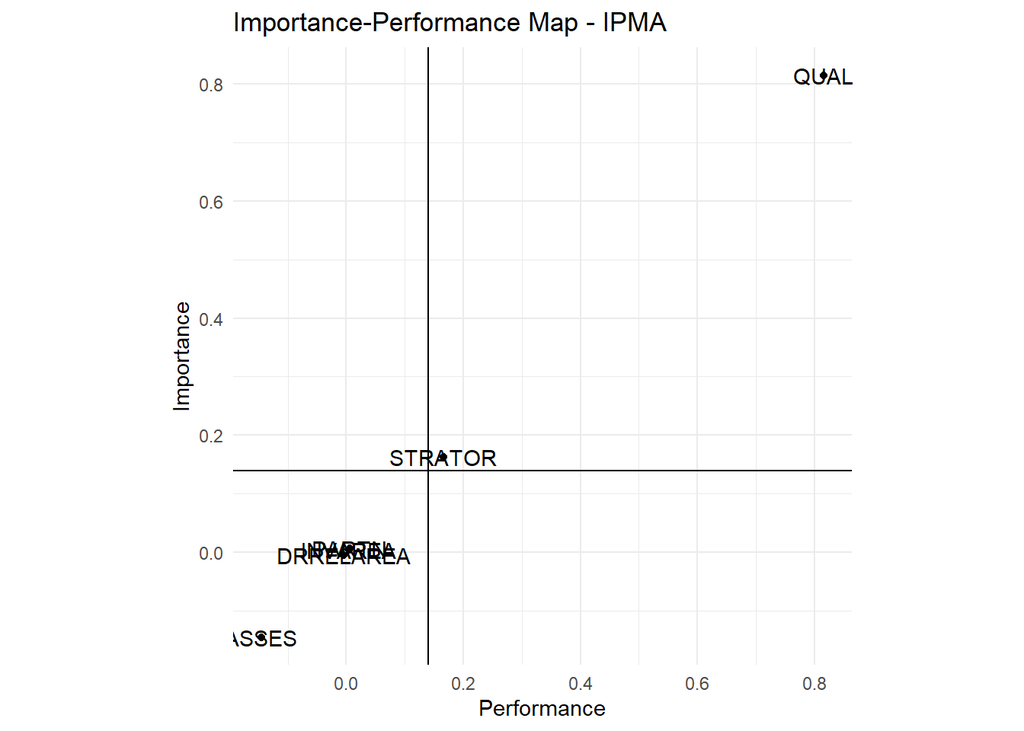

```r
betas<-model_pls1.final$path_coefs[c(7),c(1,2,3,4,5,6)]
efeitos<-model_pls1.final$effects[c(6,11,15,18,20,21),]$total
df<-data.frame(betas, efeitos)
colnames(df)<-c("BETAS","EFFECTS")
p<-ggplot(df, aes(x=efeitos, y=betas)) +
  geom_point() +
  #lims(x=c(0.67517,0.67517),y=c(-0.44522,0.44522)) +
  theme_minimal() +
  coord_fixed() +
  geom_vline(xintercept = mean(df$EFFECTS)) + geom_hline(yintercept = mean(df$BETAS)) +
    geom_text(label=rownames(df))   +
     labs(title = "Importance-Performance Map - IPMA", x = "Performance", y = "Importance")
p
```

```r
#png("ipma.png")
#print(p)
#dev.off()
```

# Validation - GOF

```r
model_pls1.final$gof
```

```
## [1] 0.6010042
```

# Validation Confidence Interval - Weights

```r
model_pls1.final$boot$weights
```

```
##                       Original Mean.Boot    Std.Error  perc.025  perc.975
## ASSES-ASSES1         0.5693484 0.5698416 1.871381e-02 0.5343596 0.6075953
## ASSES-ASSES2         0.3354102 0.3349561 1.709040e-02 0.3002999 0.3675793
## ASSES-ASSES3         0.3015996 0.3013130 1.808570e-02 0.2647579 0.3359075
## QUAL-QUAL1           1.0000000 1.0000000 8.745599e-17 1.0000000 1.0000000
## DRRELAREA-DRRELAREA1 0.3041415 0.3042077 9.868110e-03 0.2847093 0.3236293
## DRRELAREA-DRRELAREA2 0.2997206 0.2995389 9.892314e-03 0.2804977 0.3190141
## DRRELAREA-DRRELAREA4 0.3844680 0.3847203 1.285039e-02 0.3599865 0.4104167
## DRRELAREA-DRRELAREA5 0.2900736 0.2899502 9.337532e-03 0.2713435 0.3077108
## STRATOR-STRATOR2     1.0000000 1.0000000 1.344284e-16 1.0000000 1.0000000
## INVAREA-INVAREA1     1.0000000 1.0000000 9.395290e-17 1.0000000 1.0000000
## PARTN-PARTN2         1.0000000 1.0000000 1.295527e-16 1.0000000 1.0000000
## IAM-IAM              1.0000000 1.0000000 7.111341e-17 1.0000000 1.0000000
```

# Validation Confidence Interval - Loadings

```r
model_pls1.final$boot$loadings
```

```
##                       Original Mean.Boot    Std.Error  perc.025  perc.975
## ASSES-ASSES1         0.9084924 0.9085593 6.369650e-03 0.8957175 0.9206777
## ASSES-ASSES2         0.7937113 0.7932106 1.640288e-02 0.7599385 0.8238039
## ASSES-ASSES3         0.7179466 0.7172630 2.034959e-02 0.6742307 0.7539655
## QUAL-QUAL1           1.0000000 1.0000000 5.816286e-17 1.0000000 1.0000000
## DRRELAREA-DRRELAREA1 0.7770406 0.7769479 1.435384e-02 0.7470613 0.8038818
## DRRELAREA-DRRELAREA2 0.7569246 0.7565481 1.534835e-02 0.7249850 0.7856066
## DRRELAREA-DRRELAREA4 0.7969075 0.7969819 1.186731e-02 0.7730395 0.8190754
## DRRELAREA-DRRELAREA5 0.7943445 0.7940308 1.380031e-02 0.7652170 0.8199849
## STRATOR-STRATOR2     1.0000000 1.0000000 5.670319e-17 1.0000000 1.0000000
## INVAREA-INVAREA1     1.0000000 1.0000000 6.178089e-17 1.0000000 1.0000000
## PARTN-PARTN2         1.0000000 1.0000000 5.799304e-17 1.0000000 1.0000000
## IAM-IAM              1.0000000 1.0000000 5.393984e-17 1.0000000 1.0000000
```

# Validation Confidence Interval - Path Coefficients

```r
model_pls1.final$boot$paths
```

```
##                        Original    Mean.Boot  Std.Error    perc.025    perc.975
## ASSES -> IAM       -0.145341258 -0.140935956 0.01192455 -0.16459489 -0.11838075
## QUAL -> IAM         0.815441920  0.820456752 0.03001524  0.76199942  0.87811468
## DRRELAREA -> PARTN  0.110226548  0.109959935 0.02715567  0.05650061  0.16262777
## DRRELAREA -> IAM   -0.005040801 -0.004313222 0.01342199 -0.03056267  0.02182170
## STRATOR -> PARTN    0.489419400  0.489795866 0.02067527  0.44942585  0.53036597
## STRATOR -> IAM      0.162938735  0.158317570 0.02871890  0.10244978  0.21499850
## INVAREA -> IAM      0.004324685  0.004575303 0.01509831 -0.02470674  0.03337340
## PARTN -> IAM        0.006174280  0.005336246 0.01331439 -0.02023317  0.03145911
```

# Validation Confidence Interval - $R^2$

```r
model_pls1.final$boot$rsq
```

```
##        Original Mean.Boot   Std.Error  perc.025  perc.975
## PARTN 0.2993411 0.3003613 0.016144378 0.2684049 0.3321141
## IAM   0.8464210 0.8512747 0.007349294 0.8365825 0.8654128
```

# Validation Confidence Interval - Effects

```r
model_pls1.final$boot$total.efs[c(6,11,14,15,17,18,20,21),]
```

```
##                        Original    Mean.Boot  Std.Error    perc.025    perc.975
## ASSES -> IAM       -0.145341258 -0.140935956 0.01192455 -0.16459489 -0.11838075
## QUAL -> IAM         0.815441920  0.820456752 0.03001524  0.76199942  0.87811468
## DRRELAREA -> PARTN  0.110226548  0.109959935 0.02715567  0.05650061  0.16262777
## DRRELAREA -> IAM   -0.004360232 -0.003718664 0.01340343 -0.02967786  0.02212906
## STRATOR -> PARTN    0.489419400  0.489795866 0.02067527  0.44942585  0.53036597
## STRATOR -> IAM      0.165960548  0.160924697 0.02898838  0.10437917  0.21758103
## INVAREA -> IAM      0.004324685  0.004575303 0.01509831 -0.02470674  0.03337340
## PARTN -> IAM        0.006174280  0.005336246 0.01331439 -0.02023317  0.03145911
```